# individual1.Rmd

```r
library(dplyr)
```

```r
library(tidyr)
library(readxl)
library(ggplot2)
defense <- read_excel('cyclonesFootball2018.xlsx', sheet='Defensive')
str(defense)
```

```
## Classes 'tbl_df', 'tbl' and 'data.frame':    446 obs. of  11 variables:
##  $ Name             : chr  "Eisworth, Greg" "Eisworth, Greg" "Eisworth, Greg" "Eisworth, Greg" ...
##  $ Opponent_Opponent: chr  "Iowa" "Oklahoma" "Akron" "TCU" ...
##  $ Tackles_Solo     : chr  "3" "6" "7" "6" ...
##  $ Tackles_ASST     : chr  "3" "8" "2" "3" ...
##  $ Tackles_TFL      : chr  "0" "1.0" "1.0" "0" ...
##  $ Tackles_Sack     : chr  "0" "0" "0" "0" ...
##  $ Turnover_FF      : chr  "0" "1" "0" "0" ...
##  $ Turnover_FR      : chr  "0" "0" "0" "0" ...
##  $ Turnover_INT     : chr  "0" "0" "0" "0" ...
##  $ Pass_QBH         : chr  "0" "0" "0" "0" ...
##  $ Pass_PB          : chr  "0" "0" "3" "0" ...
```

```r
offense <- read_excel('cyclonesFootball2018.xlsx', sheet='Offensive')
str(offense)
```

```
## Classes 'tbl_df', 'tbl' and 'data.frame':    168 obs. of  12 variables:
##  $ Name             : chr  "Jones, Deshaunte" "Jones, Deshaunte" "Jones, Deshaunte" "Jones, Deshaunte" ...
##  $ Opponent_Opponent: chr  "Iowa" "Oklahoma" "Akron" "TCU" ...
##  $ Receiving_REC    : chr  "1" "9" "6" "3" ...
##  $ Receiving_YDS    : chr  "31" "66" "39" "23" ...
##  $ Receiving_TD     : chr  "0" "0" "0" "0" ...
##  $ Rushing_ATT      : chr  NA NA NA NA ...
##  $ Rushing_YDS      : chr  NA NA NA NA ...
##  $ Rushing_TD       : chr  NA NA NA NA ...
##  $ Passing_CMP-ATT  : chr  NA NA NA NA ...
##  $ Passing_YDS      : chr  NA NA NA NA ...
##  $ Passing_TD       : chr  NA NA NA NA ...
##  $ Passing_INT      : chr  NA NA NA NA ...
```

```r
bio <- read_excel('cyclonesFootball2018.xlsx', sheet='Biography')
str(bio)
```

```
## Classes 'tbl_df', 'tbl' and 'data.frame':    123 obs. of  7 variables:
##  $ Name      : chr  "Akers, Landen" "Allen, Chase" "Alt, Gerry" "Anderson, Cole" ...
##  $ Position  : chr  "Wide Receiver" "Tight End" "Offensive Line" "Tight End" ...
##  $ Height    : chr  "6-0" "6-7" "6-2" "6-4" ...
##  $ Weight    : chr  "192" "240" "290" "250" ...
##  $ Class     : chr  "Redshirt Sophomore" "Redshirt Sophomore" "Redshirt Freshman" "Redshirt Senior" ...
##  $ Hometown  : chr  "Cedar Rapids, Iowa" "Nixa, Mo." "Cedar Rapids, Iowa" "League City, Texas" ...
##  $ Highschool: chr  "Washington" "Nixa" "Washington" "Clear Falls" ...
```

## Cleaning Data

1. The player names and opponent names are factors.

```r
defense$Name <- factor(defense$Name)
defense$Opponent_Opponent <- factor(defense$Opponent_Opponent)

offense$Name <- factor(offense$Name)
offense$Opponent_Opponent <- factor(offense$Opponent_Opponent)

bio$Name <- factor(bio$Name)
```

2. All offensive and defensive statistics are numerical.The Weight column in biogrpahy is also numeric.

```r
defClean <- defense %>% mutate_if(is.character,as.numeric)
offClean <- offense %>% mutate_if(is.character,as.numeric)
bioClean <- bio
bioClean$Weight <- as.numeric(bioClean$Weight)
```

3. Bonus: Change the Height column in biogrpahy into numeric

```r
bioClean <- bioClean %>% separate(Height, into=c('Feet', 'Inches'))
bioClean$Feet <- as.numeric(bioClean$Feet)
bioClean$Inches <- as.numeric(bioClean$Inches)
bioClean <- bioClean %>% mutate('Height (in Inches)' = Feet*12 + Inches)
bioClean <- bioClean %>% select(-Feet, -Inches)
```

Separated the `Height` column into `Feet` and `Inches` in order to introduce `Height (in Inches)` column as a numeric.

```r
str(defClean)
```

```
## Classes 'tbl_df', 'tbl' and 'data.frame':    446 obs. of  11 variables:
##  $ Name             : Factor w/ 42 levels "Akers, Landen",..: 7 7 7 7 7 7 7 7 7 7 ...
##  $ Opponent_Opponent: Factor w/ 13 levels "Akron","Baylor",..: 4 7 1 9 8 13 11 5 2 10 ...
##  $ Tackles_Solo     : num  3 6 7 6 3 5 3 7 2 9 ...
##  $ Tackles_ASST     : num  3 8 2 3 0 3 2 1 4 3 ...
##  $ Tackles_TFL      : num  0 1 1 0 1 1 0 0 0 0 ...
##  $ Tackles_Sack     : num  0 0 0 0 0 1 0 0 0 0 ...
##  $ Turnover_FF      : num  0 1 0 0 0 0 0 0 0 1 ...
##  $ Turnover_FR      : num  0 0 0 0 0 0 0 0 0 0 ...
##  $ Turnover_INT     : num  0 0 0 0 0 0 1 0 0 0 ...
##  $ Pass_QBH         : num  0 0 0 0 0 0 0 0 0 0 ...
##  $ Pass_PB          : num  0 0 3 0 0 0 0 0 0 0 ...
```

```r
str(offClean)
```

```
## Classes 'tbl_df', 'tbl' and 'data.frame':    168 obs. of  12 variables:
##  $ Name             : Factor w/ 15 levels "Akers, Landen",..: 6 6 6 6 6 6 6 6 6 6 ...
##  $ Opponent_Opponent: Factor w/ 13 levels "Akron","Baylor",..: 4 7 1 9 8 13 11 5 2 10 ...
##  $ Receiving_REC    : num  1 9 6 3 6 1 1 4 4 0 ...
##  $ Receiving_YDS    : num  31 66 39 23 37 32 4 31 39 0 ...
##  $ Receiving_TD     : num  0 0 0 0 1 1 0 0 1 0 ...
##  $ Rushing_ATT      : num  NA NA NA NA NA NA NA NA NA NA ...
##  $ Rushing_YDS      : num  NA NA NA NA NA NA NA NA NA NA ...
##  $ Rushing_TD       : num  NA NA NA NA NA NA NA NA NA NA ...
##  $ Passing_CMP-ATT  : num  NA NA NA NA NA NA NA NA NA NA ...
##  $ Passing_YDS      : num  NA NA NA NA NA NA NA NA NA NA ...
##  $ Passing_TD       : num  NA NA NA NA NA NA NA NA NA NA ...
##  $ Passing_INT      : num  NA NA NA NA NA NA NA NA NA NA ...
```

```r
str(bioClean)
```

```
## Classes 'tbl_df', 'tbl' and 'data.frame':    123 obs. of  7 variables:
##  $ Name              : Factor w/ 123 levels "Akers, Landen",..: 1 2 3 4 5 6 7 8 9 10 ...
##  $ Position          : chr  "Wide Receiver" "Tight End" "Offensive Line" "Tight End" ...
##  $ Weight            : num  192 240 290 250 191 205 192 224 251 284 ...
##  $ Class             : chr  "Redshirt Sophomore" "Redshirt Sophomore" "Redshirt Freshman" "Redshirt Senior" ...
##  $ Hometown          : chr  "Cedar Rapids, Iowa" "Nixa, Mo." "Cedar Rapids, Iowa" "League City, Texas" ...
##  $ Highschool        : chr  "Washington" "Nixa" "Washington" "Clear Falls" ...
##  $ Height (in Inches): num  72 79 74 76 72 71 72 75 74 74 ...
```

## Tidy Data

4. Reformat the defClean data frame into a tidy format using gather. The type of statistic (Tackles_Solo, Tackles_ASST, etc) is added as a new key column named Statistic.

```r
defClean <- defClean %>% gather(key=Statistic, value=val, 3:11)
```

5. Create a histogram for each defensive statistic. Use facet_wrap to draw all histograms in a single plot. What defensive skills are rare?

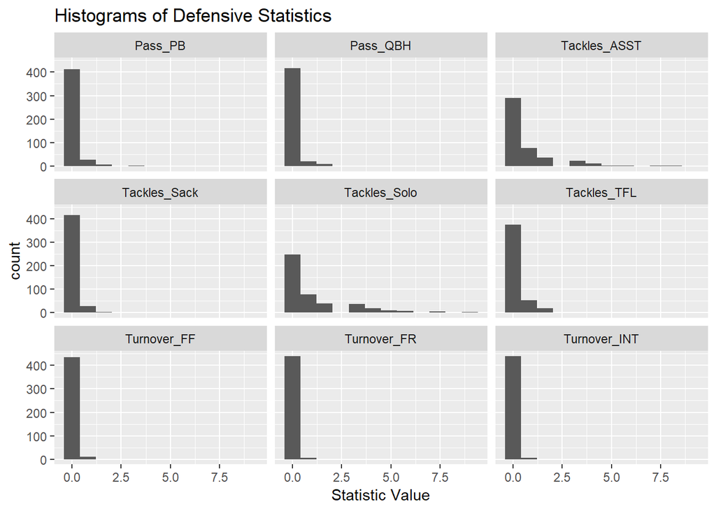

```r
ggplot(defClean, aes(x=val)) + geom_histogram(bins=12) + facet_wrap(~ Statistic) + xlab('Statistic Value') + ggtitle('Histograms of Defensive Statistics')
```

Turnovers are rare defensive skills (see histograms for `Turnover_FF`, `Turnover_FR`, and `Turnover_INT`). From the histograms we can see that a majority of the time, players will perform 0 of each of these skills per game. Defensive players rarely perform any kind of Turnover in a game.

6. Did ISU have better defense against West Virginia or Kansas State? Answer this question by creating a scatterplot with x-axis being the number of solo tackles (by each player) against West Virginia, and y-axis being that against Kansas State. A large number of solo tackles indicates good defense.

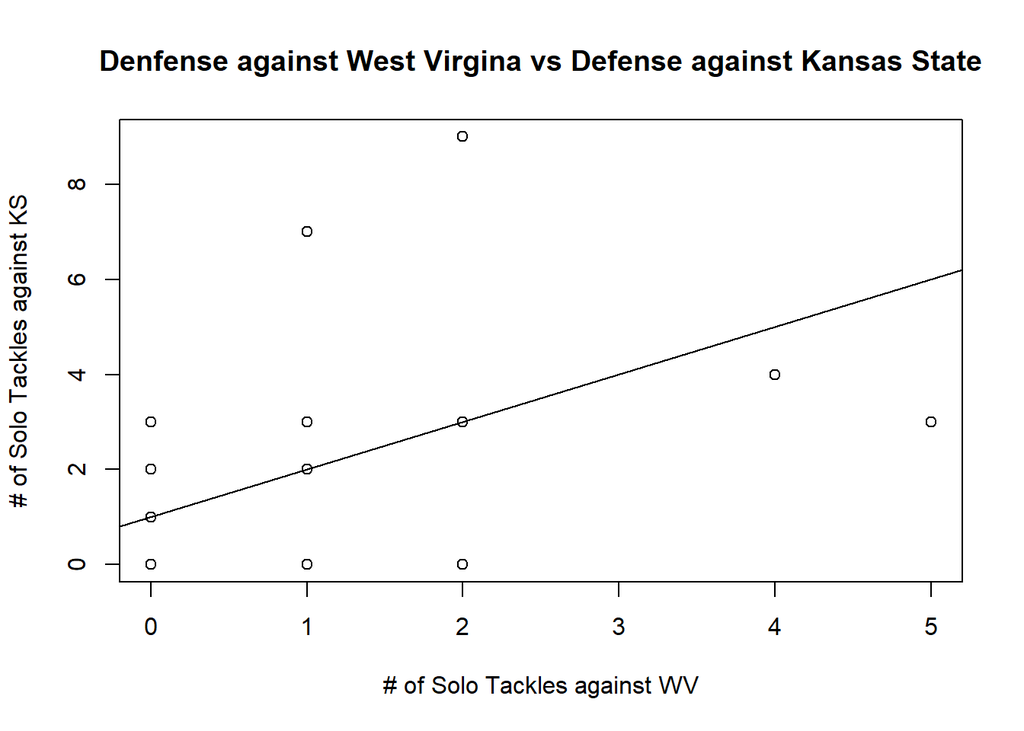

```r
wv <- defClean %>% filter(Opponent_Opponent=='West Virginia' & Statistic == 'Tackles_Solo')
ks <- defClean %>% filter(Opponent_Opponent=='Kansas State' & Statistic == 'Tackles_Solo')
ks <- ks %>% filter(Name != 'White, Lawrence')

plot(wv$val, ks$val, main="Denfense against West Virgina vs Defense against Kansas State",  xlab="# of Solo Tackles against WV", ylab="# of Solo Tackles against KS")
abline(a=1, b=1)
```

Lawrence White played in the game against Kansas State, but not in the game against West Virginia, so we need to remove his data in order to create the plot.

```r
WVsoloTackles <- sum(wv$val)
KSsoloTackles <- sum(ks$val)
WVsoloTackles
```

```
## [1] 25
```

```r
KSsoloTackles
```

```
## [1] 43
```

In total, ISU got 43 solo tackles against KS and 25 against WV. From this data, it appears ISU had a better defense against Kansas State than they did against West Virginia.

7. Separate the Hometown column into two columns, namely the city and the state. Print the first few rows of these two columns. (Hint: look at the sep= argument of separate)

```r
bioClean <- bioClean %>% separate(Hometown, into=c('City', 'State'), sep=", ")
bioClean %>% select(City, State) %>% head()
```

```
## # A tibble: 6 x 2
##   City         State
##   <chr>        <chr>
## 1 Cedar Rapids Iowa
## 2 Nixa         Mo.
## 3 Cedar Rapids Iowa
## 4 League City  Texas
## 5 Naperville   Ill.
## 6 Walnut       Calif.
```

8. How many players are there from each state?

```r
bioClean$State <- factor(bioClean$State)
table(bioClean$State)
```

```
##
##     Ariz.      Ark. Australia    Calif.      D.C.      Fla.       Ga.
##         3         2         2         8         1         8         2
##      Ill.      Iowa      Kan.     Mass.       Md.     Mich.     Minn.
##         5        44         3         1         1         5         2
##     Miss.       Mo.      Neb.   Nigeria      Ohio     Okla.       Pa.
##         1         1         1         1        10         4         2
##      S.C.     Texas       Va.      Wis.
##         2         9         1         4
```

NOTE: Australia and Nigeria are not states, but are included because players from outside the U.S. have a country, rather than a state, associated with their hometown.

## Joining Data Frames

9. Find where do the offensive players come from by joining the offensive data and player biography data appropriately.

```r
offBio <- semi_join(bioClean, offClean)
table(offBio$State)
```

```
##
##     Ariz.      Ark. Australia    Calif.      D.C.      Fla.       Ga.
##         1         1         0         0         0         2         0
##      Ill.      Iowa      Kan.     Mass.       Md.     Mich.     Minn.
##         0         1         0         0         1         0         0
##     Miss.       Mo.      Neb.   Nigeria      Ohio     Okla.       Pa.
##         0         1         0         0         3         1         0
##      S.C.     Texas       Va.      Wis.
##         0         1         1         1
```

3 offensive players are from Ohio and 2 are from Florida. There is 1 offensive player from each of the folllowing states: Arizona, Arkansas, Iowa, Maryland, Missouri, Oklahoma, Texas, Virginia, and Wisconsin.

10. Is there a relationship between the weight of a player and the receiving yards (Receiving_YDS)?

```r
weightYDS <- inner_join(offClean, bioClean)
```

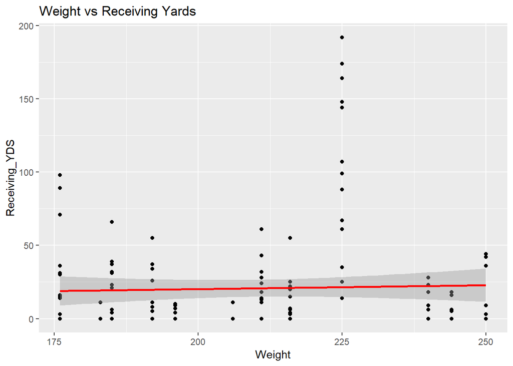

```r
ggplot(weightYDS, aes(x=Weight, y=Receiving_YDS)) + geom_point() +   stat_smooth(method = "lm", col = "red") + ggtitle("Weight vs Receiving Yards")
```

First create a scatterplot of `Weight` by `Receiving_YDS`, then plot the linear regression line between the two variables. From this plot, there does not appear to be a relationship between `Weight` and `Receiving_YDS`, as the linear regression line is nearly horizontal and the points are not clustered along the line.

11. Explore more. Raise a question that can be answered only by looking at two or more data frames. Then answer that question.

**Are more offensive players from Iowa or more defensive players from Iowa?**

```r
table(offBio$State)
```

```
##
##     Ariz.      Ark. Australia    Calif.      D.C.      Fla.       Ga.
##         1         1         0         0         0         2         0
##      Ill.      Iowa      Kan.     Mass.       Md.     Mich.     Minn.
##         0         1         0         0         1         0         0
##     Miss.       Mo.      Neb.   Nigeria      Ohio     Okla.       Pa.
##         0         1         0         0         3         1         0
##      S.C.     Texas       Va.      Wis.
##         0         1         1         1
```

```r
defBio <- semi_join(bioClean, defClean)
table(defBio$State)
```

```
##
##     Ariz.      Ark. Australia    Calif.      D.C.      Fla.       Ga.
##         0         1         1         4         1         7         0
##      Ill.      Iowa      Kan.     Mass.       Md.     Mich.     Minn.
##         1        11         1         0         1         1         1
##     Miss.       Mo.      Neb.   Nigeria      Ohio     Okla.       Pa.
##         1         0         0         0         4         1         1
##      S.C.     Texas       Va.      Wis.
##         0         4         0         1
```

11 defensive players are from Iowa whereas only 1 offensive player is from Iowa. Compare the total number of defensive players to the total number of offensive players to determine percentage of players from Iowa.

```r
length(offBio$Name)
```

```
## [1] 14
```

```r
length(defBio$Name)
```

```
## [1] 42
```

1 of the 14 offensive players is from Iowa and 11 of the 42 defensive players are from Iowa. This means about 7% of offensive players are from Iowa, whereas about 26% of defensive players are from Iowa. Therefore, more defensive players are from Iowa than offensive players.